# SIM

husnafanyn

2026-04-10

```r
# Memuat paket yang diperlukan untuk visualisasi
library(DBI)
library(odbc)
library(ggplot2)
library(scales)
```

# Penulisan Dengan Struktur Markdown

Dokumen ini menyajikan hasil analisis data dengan memanfaatkan **R-Markdown** sebagai alat utama dalam pengolahan dan penyusunan laporan. Dengan integrasi **HTML**, tampilan laporan menjadi lebih *dinamis* dan **fleksibel**, memungkinkan penyajian tabel, gambar, serta elemen interaktif yang tidak dapat dicapai hanya dengan Markdown biasa.

Kombinasi kedua teknologi ini memberikan kemudahan dalam menyusun laporan yang tidak hanya **informatif**, tetapi juga lebih **profesional** dan mudah dibaca. Selain itu, penggunaan **CSS** dalam HTML semakin memperkaya estetika tampilan, menjadikan dokumen lebih menarik dan sesuai dengan standar penyajian visual yang baik.

Dengan pendekatan ini, analisis data dapat dikomunikasikan secara lebih **jelas** dan **efektif** kepada pembaca.

**Referensi tambahan:**

🔗[Dokumentasi R-Markdown](https://rmarkdown.rstudio.com/)

# Penulisan Dengan tag html

**R-Markdown** memberikan kemudahan dalam menyusun laporan berbasis data dengan struktur yang ringkas dan fleksibel.

Dengan dukungan **HTML**, pengguna dapat memperkaya tampilan dokumen menggunakan elemen seperti tabel, gambar, dan format teks yang lebih *variatif*.

Selain itu, integrasi dengan **CSS** memungkinkan personalisasi gaya agar laporan lebih *estetis* dan profesional, mulai dari pemilihan warna, font, hingga tata letak elemen.

Kombinasi ketiga teknologi ini membantu menyampaikan analisis data secara lebih **jelas** dan **terstruktur**, sehingga pembaca dapat memahami hasil dengan lebih mudah.

Dengan pendekatan ini, penyusunan laporan menjadi lebih **efisien** dan menarik tanpa mengorbankan keakuratan informasi yang disajikan.

🔗 [Pelajari lebih lanjut tentang R-Markdown](https://rmarkdown.rstudio.com/)

# Data

Proses ini mengintegrasikan **SQL** untuk pengambilan data dan **R** untuk visualisasi.

## Koneksi Data

Langkah pertama adalah membangun koneksi antara RStudio dan database MySQL menggunakan fungsi `dbConnect()`

```r
con = dbConnect(odbc(),
                 Driver = "MySQL ODBC 8.0 ANSI Driver",
                 Server = "127.0.0.1",
                 UID = "root",
                 PWD = "lup4p4ssw0rd",
                 Port = 3306,
                 database = "classicmodels")
```

## Ambil Data

Setelah koneksi terjalin, kita menggunakan blok kode SQL untuk mendapatkan data nilai pesanan di negara Nordic. Simpan data hasil kueri data dalam suatu data frame R.

```r
query <- "SELECT o.ordernumber, country, sum(quantityordered*priceeach) as total_value
FROM orders o
JOIN orderdetails od ON o.orderNumber=od.orderNumber
JOIN customers c ON o.customerNumber=c.customerNumber
WHERE country IN ('Denmark', 'Finland', 'Norway', 'Sweden')
GROUP BY o.orderNumber"

data <- dbGetQuery(con, query)
```

## Ringkasan Data

Ringkasan data merupakan ringkasan statistik deskriptif dari data, seperti nilai minimum, kuartil pertama, median, mean (rata-rata), kuartil ketiga, dan maksimum untuk data numerik, serta hitungan kategori untuk data faktor.

```r
knitr::kable(data,
             caption = "Data Nilai Pesanan Negara Nordic",
             col.names = c("Order Number", "Country", "Total Value"))
```

Data Nilai Pesanan Negara Nordic

| Order Number | Country | Total Value |
| --- | --- | --- |
| 10103 | Norway | 50218.95 |
| 10105 | Denmark | 53959.21 |
| 10112 | Sweden | 7674.94 |
| 10141 | Finland | 29716.86 |
| 10151 | Finland | 32723.04 |
| 10155 | Finland | 37602.48 |
| 10158 | Norway | 1491.38 |
| 10161 | Denmark | 36164.46 |
| 10167 | Sweden | 44167.09 |
| 10181 | Norway | 55069.55 |
| 10188 | Norway | 29954.91 |
| 10238 | Denmark | 28211.70 |
| 10239 | Finland | 16212.59 |
| 10247 | Finland | 28394.54 |
| 10256 | Denmark | 4710.73 |
| 10284 | Norway | 32260.16 |
| 10289 | Norway | 12538.01 |
| 10291 | Sweden | 48809.90 |
| 10299 | Finland | 34341.08 |
| 10301 | Norway | 36798.88 |
| 10309 | Norway | 17876.32 |
| 10314 | Denmark | 53745.34 |
| 10320 | Sweden | 16799.03 |
| 10325 | Norway | 34638.14 |
| 10326 | Sweden | 19206.68 |
| 10327 | Denmark | 20564.86 |
| 10334 | Sweden | 23014.17 |
| 10363 | Finland | 45785.34 |
| 10373 | Finland | 46770.52 |
| 10377 | Finland | 23602.90 |
| 10389 | Sweden | 27966.54 |
| 10406 | Denmark | 21638.62 |

```r
summary(data)
```

```
##   ordernumber      country           total_value
##  Min.   :10103   Length:32          Min.   : 1491
##  1st Qu.:10166   Class :character   1st Qu.:20225
##  Median :10286   Mode  :character   Median :29836
##  Mean   :10257                      Mean   :30395
##  3rd Qu.:10325                      3rd Qu.:39244
##  Max.   :10406                      Max.   :55070
```

## Contoh Membuat Tabel Data Secara Manual

| Order Number | Country | Total Value |
| --- | --- | --- |
| 20001 | Norway | 50000 |
| 20002 | Denmark | 100000 |

# Analisis Data

Laporan ini menyajikan analisis data untuk nilai pesanan dari negara-negara Nordic dari database *classicmodels*.

## Menambahkan Gambar

### Menambahkan Gambar dengan sintaks Markdown

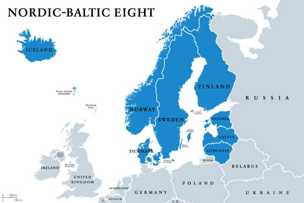

Gambar 1. Peta Negara-Negara Nordic dengan sintaks Markdown

### Menambahkan Gambar dengan tag HTML

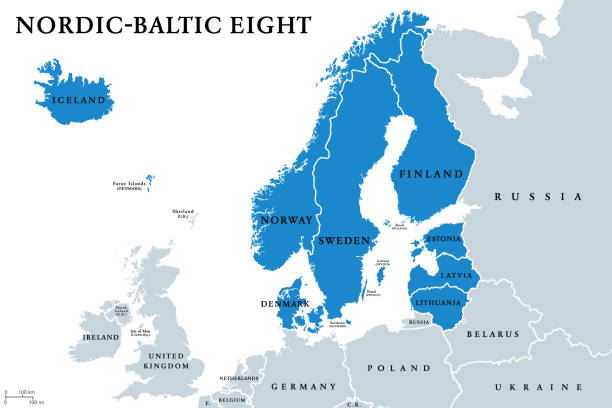

Gambar 2. Peta Negara-Negara Nordic dengan tag HTML

Kita menggunakan library `ggplot2` untuk membuat histogram. Fungsi `geom_histogram()` digunakan untuk melihat distribusi frekuensi nilai pesanan.

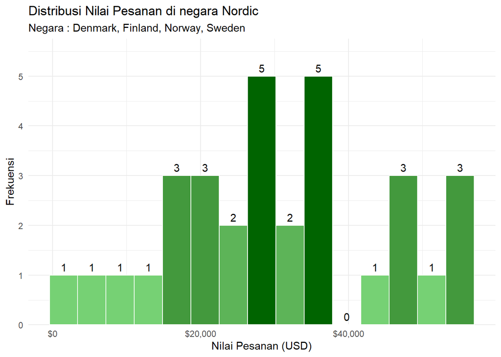

```r
# Membuat histogram dari nilai pesanan

ggplot(data, aes(x = total_value)) +
  geom_histogram(aes(fill = after_stat(count)),
                 bins = 15, color='white') +
  stat_bin(bins = 15, geom = "text",
           aes(label =after_stat(count)), vjust=-0.5)+
  scale_fill_gradient(low='lightgreen', high = 'darkgreen')+
  scale_x_continuous(labels = label_dollar())+
  scale_y_continuous(expand = expansion(c(0,0.15)))+
  theme_minimal() +
  labs(title = "Distribusi Nilai Pesanan di negara Nordic",
       subtitle = "Negara : Denmark, Finland, Norway, Sweden",
       x = "Nilai Pesanan (USD)",
       y = "Frekuensi") +
  theme(legend.position = "none")
```

# Referensi Cheat Sheet untuk Penggunaan CSS

🔗 [Referensi Cheatsheet CSS](https://htmlcheatsheet.com/css/)